# Theory on Time series

Data obtained from observations collected sequentially over time are extremely common [1].

**Time series analysis** is the effort of extracting insightful summary and statistical information from observations arranged in chronological order [2].

several possible objectives in analysing a time series [2]:

- description
  - look for outliers; robust methods to be insensitive to outliers are needed
  - sudden or gradual changes in the series: **seasonal changes**, **step changes**, **turning points**
- explanation
  - use one time series to explain another
- prediction
  - use existing time series data to predict future obs. of the time series
- control
  - assess and maintain/control performances of processes

# concepts

- **deterministic**: if a time series can be predicted exactly
- **stochastic**: a sequence of random variables $Y_t: t=0, 1,2, \dots$
  - future obs. are partially determined by past obs.
  - so that future values have a probabilistic distribution conditioned on past values.
- **autocovariance function**, $\gamma_{t,s}=Cov(Y_t, Y_s)$ for time point t and s
  - $\gamma_{t,t}=Var(Y_t)$
  - $\gamma(t,s)=\gamma(s,t)$
  - $|\gamma_{t,s}|\le \sqrt{\gamma_{t,t} \gamma_{s,s}}$
  - $\gamma_k=\frac{\sum_{t=1}^{N-k}(y_t-\bar{y})(y_{t+k}-\bar{y}))}{N}, k=0,1,2,\dots$ gives the **autocovariance coefficients at lag k** between obs. that are k steps apart.
- **autocorrelation function**, $\rho_{t.s}=Corr(Y_t, Y_s)$ for time point t and s
  - $\rho_{t,t}=1$
  - $\rho_{t,s}\le 1$
  - $\rho_1=\frac{\sum_{t=1}^{N-1}(y_t-\bar{y})(y_{t+1}-\bar{y}))}{\sum_{t=1}^{N}(y_t-\bar{y})^2}$
  - $\rho_k=\frac{\sum_{t=1}^{N-k}(y_t-\bar{y})(y_{t+k}-\bar{y}))}{\sum_{t=1}^{N}(y_t-\bar{y})^2}, k=0,1,2,\dots$ gives the **sample autocorrelation coefficient at lag k** between obs. that are k steps apart.
  - $\rho_k=\gamma_k/\gamma_0$
- time series classification
  - **continuous**: obs. are made continuously even the response takes only a discrete set of values
  - **discrete**: obs. are taken at specific times, such as equally spaced, even the response is continuous
    - arises in several ways: sampled at equal time intervals; aggregate/accumulate the values over equal intervals of time such as daily rainfalls
- assumptions to simplify time series data structure
  - strickly stationarity
    - if the joint distribution of $Y_{t_1}, Y_{t_2}, \dots, Y_{t_n}$ is the same as the join distribution of $Y_{t_1-k}, Y_{t_2-k}, \dots, Y_{t_n-k}$ for all time points $t_1, t_2, \dots, t_n$ and time lag k.
  - weakly stationary

# examples

- first example: let $e_1, \dots, e_n$ be a sequence of iid random variables with mean 0 and variance $\sigma^2$
  - construct a time series as follows:

  $$\begin{aligned}
  Y_1&=e_1 \\
  Y_2&=e_1+e_2 \\
  \vdots \\
  Y_t &= e_1+e_2+\dots+e_t
  \end{aligned}$$
  or $Y_t=Y_{t-1}+e_t$ with initial condition $Y_1=e_1$. here we have $E[Y_t]=0, var[Y_t]=t\sigma^2$ where variance increases linearly with time t. covariance for $1 \le t \le s$, $\gamma_{t,s}=Cov(Y_t, Y_s)=\sum_{i=1}^{s}\sum_{j=1}^{t}Cov(e_i, e_j)=t\sigma^2$; the autocorrelation for the random walk is given as $\rho_{t,s}=\frac{\gamma_{t,s}}{\sqrt{\gamma_{t,t}\gamma_{s,s}}}=\frac{t\sigma^2}{\sqrt{t\sigma^2\cdot s\sigma^2}}=\sqrt{\frac{t}{s}}$ for $1 \le t \le s$.
  - realization of the auto-correlations:

  $$\rho_{1,2}=\sqrt{\frac{1}{2}}=0.707, \rho_{8,9}=\sqrt{\frac{8}{9}}=0.943
  \\
  \rho_{24,25}=\sqrt{\frac{24}{25}}=0.980,
  \rho_{1,9}=\sqrt{\frac{1}{9}}=0.333$$
  the obs. of Y at neighboring time points are more and more positively correlated as time goes by; the obs. of Y at distant time points are less and less correlated.

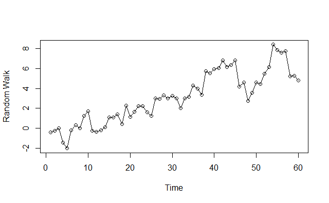

The simple random walk process provides a good approximation for phenomena as diverse as the movement of common stock price, and the movement of small particles in a fluid—so-called **Brownian motion**.

- second example: a moving average

let $\{Y_t\}$ be consisted if $Y_t=\frac{e_t+e_t-1}{2}$ where $e_i \overset{iid}{\sim} f(0, \sigma^2)$. $\mu_t=E[Y_t]=\frac{E(e_t)+E(e_{t-1})}{2}=0, var(Y_t)=\frac{\sigma^2}{2}, \gamma_{t,s}=\begin{cases}0.5 \sigma^2, |t-s|=0 \\ 0.25\sigma^2, |t-s|=1 \\ 0, |t-s|>1\end{cases}$ for all t, and $\rho_{t,s}=\begin{cases}1, |t-s|=0 \\ 0.5, |t-s|=1, \\ 0, |t-s|>1\end{cases}$.

note that $\rho_{2,1}=\rho_{3,2}=\rho_{4,3}=\rho_{9,8}=0.5$. $\rho_{3,1}=\rho_{4,2}=\rho_{t,t-2}$, and $\rho_{t,t-k}$ is the same for all t.

- third example

The classic Beveridge wheat price index series consists of the average wheat price in nearly 50 places in various countries measured in successive years from 1500 to 1869.

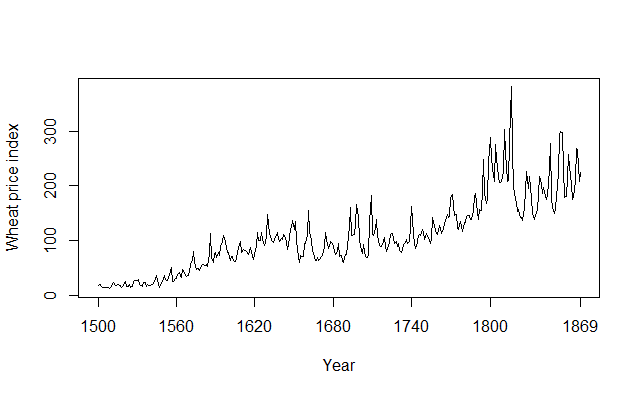

# descriptive techniques

- variation decomposition
  - trend: long-term change in the mean level
    - stationary time series: if there is no systematic change in the mean (no trend), if there is no systematic change in variance, and if periodic variations have been removed.
  - seasonal variation: seasonal changes in sales data for example
  - other cyclic changes: changes occur at a fixed period, economic data has 3-4 years cyclic period.
  - remaining irregular fluctuations: residuals in addition to trend and cyclic variations, that might or might not be random.
- time plot
  - trend
  - seasonality
  - outliers
  - discontinuities
- trend without seasonality techniques
  - curve fitting: polynomial curve, logistic curve, and so on
  - linear filter:converts one time series into another by linear operations $y_t=\sum a_rx_{t+r}$ where $\sum a_r=1$ and $\{a_r\}$ is a set of weights.
  - filters in series: smoothing carried out in two or more stages
  - differencing
- trend with seasonal variation techniques
  - additive/multiplicative seasonal effect
- autocorrelation and the correlogram
  - correlogram: the sample autocorrelation coefficients $\rho_k$ are plotted against the lag k.
  - interpreting the correlogram
    - random series: $\rho_k \approx 0, k=1,2, \dots$
    - short-term correlation
    - alternating series
    - non-stantionary series: contains a trend
    - seasonal series

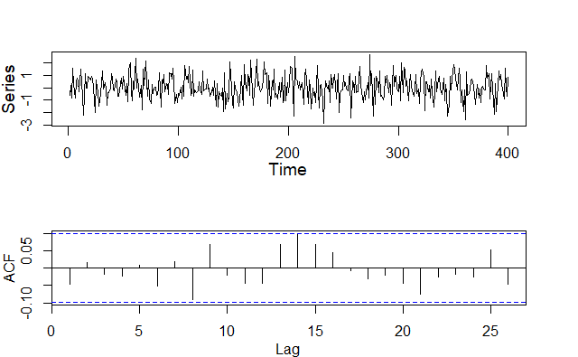

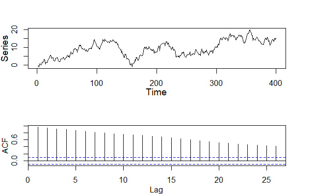

- transformation
  - stabilize the variance: transform when variance tend to increase with the mean
  - make seasonal effect additive
  - make data normally distributed
- data cleaning
  - modify outliers
  - handle missing obs.

# some linear time series models

a particular realization of a stochastic process gives observed time series. time-series analysis is essentially concerned with evaluating the properties of the underlying probabilistic model from the realized time series.

many models for stochastic processes are expressed by means of an algebraic formula relating the random variable at time t to past values of the process, together with residuals. first and second moment, autocovariance and autocorrelation function of the process are given in concepts.

## stationary processes

stationary are a important class of stochastic process:

- **strictly stationary**: if the joint distribution of $Y(t_1), \dots, Y(t_k)$ is the same as that of $Y(t_1+\tau), \dots, Y(t_k+\tau)$ for all time points and $\tau$. for example, $k=1$, stationary time series has obs. at all time times from iid random variables.
- **weakly stationary**: No requirements are placed on moments higher than second order.
  - **normal processes**

## properties of autocorrelation function

- $\rho(\tau)=\rho(-\tau))$: $Cov[Y(t), Y(t+\tau)]=Cov[Y(t-\tau),Y(t)]$
- $|\rho(\tau)| \le 1$
- the autocorrelation function des not uniquely define the underlying probabilistic model

## purely random processes

a discrete-time process is called purely random if it consists of a sequence of iid random variables $Y(t)$. we further assume $Y(t) \sim N(0, \sigma^2)$. Thus, $\gamma(k)=Cov(Y(t), Y(t+k))=\begin{cases}\sigma^2, k = 0 \\ 0,k \ne 0\end{cases}, \rho(k)=\begin{cases} 1, k=0 \\ 0, k \ne 0\end{cases}$. purely random process is also weakly and strictly **stationary** as the **mean** and **autocorrelation function** do not rely on time.

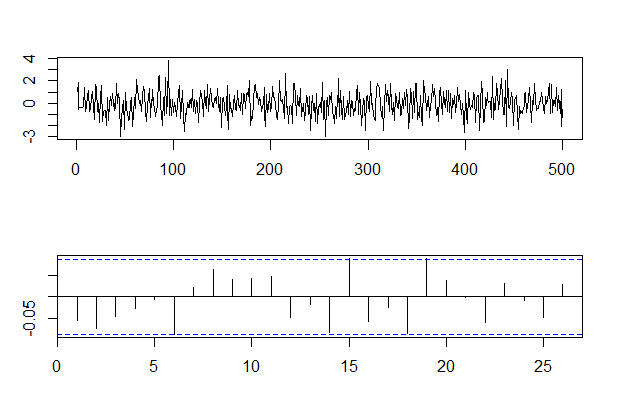

## random walks

suppose the sequence $\{Y(t)\}$ is a discrete-time, purely random process and $Y(t) \sim f(\mu, \sigma^2)$. $X(t)$ is a random walk if $X(t)=X(t-1)+Y(t)$. We let $Y(0)=0$, thus we have $X(1)=Y(1)$ and $X(t)=\sum_{i=1}^{t}Y(i), E[X(t)]=\mathbf{t}\mu, var[X(t)]=\mathbf{t}\sigma^2$. We see that the mean and variance depend on time $\mathbf{t}$, thus the random walks processes are not **stationary**.

a good example for random walks is share prices on successive days: share price on day t = share price on day (t-1) + random error.

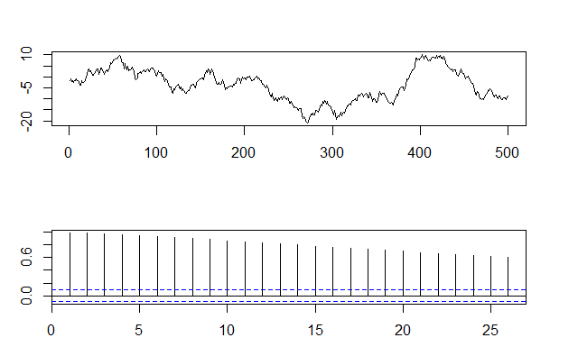

## moving average process

suppose the sequence $\{Y(t)\}$ is a discrete-time, purely random process, i.e., $Y(t) \sim f(0, \sigma^2)$ and $Y(t) \sim f(\mu, \sigma^2)$. $X(t)$ is a moving average process of order $q$ if $X(t)=\beta_0Y(t)+\beta_1Y(t-1)+\dots+\beta_q Y(t-q)$ where $\{\beta_i\}$ are constants. The $\{Y\}$s are usually scaled such that $\beta_0=1$.

$E[X(t)]=E[\beta_0Y(t)+\beta_1Y(t-1)+\dots+\beta_q Y(t-q)]=0, var[X(t)]=\sigma^2 \sum_{i=0}^{q}\beta_i^2$.

$$\rho(k)=
\begin{cases}
1, & k=0 \\
\sum_{i=0}^{q-k}\beta_i\beta_{i+k}/\sum_{i=0}^{q}\beta_i, &
k=1,\dots, q \\
0, & k>q \\
\rho(-k), & k < 0
\end{cases}$$

the autocovariance/autocorrelation function does not depend on time t and the mean in constant, the moving average (MA) process is second-order stationary; if $Y(t)$s are normally distributed, then the MA process is strictly stationary normal process.

simulate a MA(1) white noise process, $Y(t) \sim N(0,1), X(t)=Y(t)-0.8Y(t-1)$, and MA(2) process, $X(t)=Y(t)+0.7Y(t-1)-0.2Y(t-2)$:

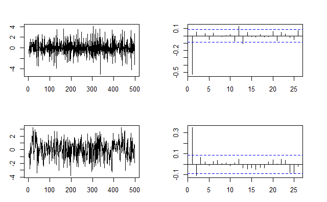

no requirements on the $\{\beta_i\}$ for a MA process to be stationary, but generally it is desirable to impose some restrictions so that the process is **invertable**. theimposition of the invertibility condition ensures that there is a unique ivertibke first-order MA process for a given autocorrelation function.

## autoregressive processes

let the sequence $\{Y(t)\}$ is a discrete-time, purely random process, i.e., $Y(t) \sim f(0, \sigma^2)$ and $Y(t) \sim f(\mu, \sigma^2)$. $X(t)$ is a **autoregressive process** of order $p$, AR(p), if $X(t)=\alpha_1X(t-1)+\dots+\alpha_pX(t-p)+Y(t)$.

- first-order AR process: $X(t)=\alpha_1X(t-1)+Y(t)$, AR(1) process is also referred to as the **Markov process**.

$$\begin{aligned}
X(t) &= \alpha X(t-1)+Y(t) \\
&= \alpha(\alpha X(t-2)+Y(t-1))+Y(t) \\
&= \alpha[\alpha (\alpha X(t-3)+Y(t-2))+Y(t-1)]+Y(t) =
\alpha^3X(t-3)+\alpha^2Y(t-2)+\alpha Y(t-1) +Y(t) \\
&=Y(t) + \alpha Y(t-1) + \alpha^2Y(t-2)+\dots
\end{aligned}$$
where $-1 < < 1 $. $E[X(t)]=0, var[X(t)]=\sigma^2 (1+\alpha^2 + \alpha^4 + \cdots)$. $\gamma(k)=\alpha^k\sigma^2/(1-\alpha^2)$, which does not depend on time t, thus an AR(1) process is second-order stationary provided that $|\alpha|<1$.

three AR(1) examples are given below with $\alpha=0.8, -0.8, 0.3$:

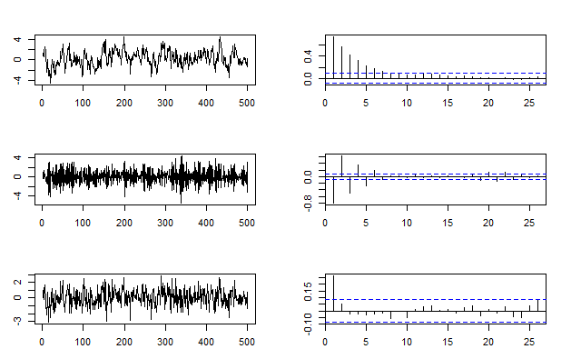

Note how quickly the ac.f. decays when $\alpha = 0.3$, and note how the ac.f. alternates when $\alpha < 0$.

AR processes have been applied to many situations in which it is reasonable to assume that the present value of a time series depends linearly on the immediate past values together with a random noise.

## mixed AR-MA models

combining AR and MA processes gives rise to amixed autoregressive/moving-average process with p AR terms and q MA terms, denoted by **ARMA(p, q)**, and formulated by :
$$X(t)=
\alpha_1X(t-1)+\dots+\alpha_pX(t-p)+Y(t)+\beta_1Y(t-1)+\dots+\beta_q
Y(t-q)$$

importance o ARMA model lies in the fact that a stationary time series can be well modelled by an ARMA model with fewer parameters than a pure AR or MA process. [**Principle of Parsimony**]

consider ARMA(1,1) and ARMA(2,2):

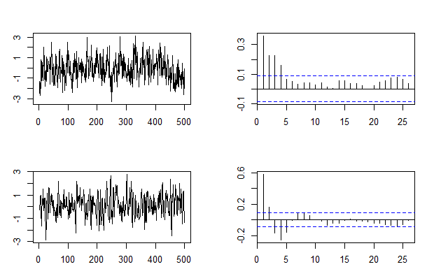

## integrated ARMA process (ARIMA)

non-stationary time seris are the most common in practice. To use the stationary models mentioned above, we need to first remove non-stationary sources of variation.

- if the observed time series is non-stationary in the mean, we can
  - difference the series
  - fit a stationary model to the differenced data

such as model is called an “integrated” model since the stationary model fitted to the differenced data has to be summed or integrated to provide a adequate model for the original non-stationary data, writing as $W(t)=\Delta^dX(t)=(1-B)^dX(t)$.

the general autoregressive integrated moving average (**ARIMA**) process takes the form of

$$W(t)=\alpha_1W(t-1)+\dots+\alpha_pW(t-p)+Y(t)+\beta_1Y(t-1)+\dots+\beta_qY(t-q)$$
ARIMA models are commonly used to remove a trend from the data. if $d=0$, ARIMA(p,d,q) models are an ARMA(p, q) process. An example of ARIMA(1,1,1) is given below:

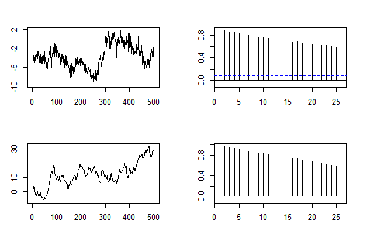

Note that the ac.f. of the two integrated processes is slowly decaying because of the trend. ARIMA models can be generalized to include seasonal terms.

## fractional differencing and long-memory models

an variant of ARIMA models arises with the use of fractional differencing, leading to fractional integrated ARMA model (ARFIMA). ARFIMA models is exactly the same as an ARIMA(p,d,q) model, except that d is no longer restricted to being an integer.

if $0 < d < 0.5$, a ARFIMA model is of particular interest because such a process is not only stationary, but is also a **long-memory** model. By long-memory, we try to express the speed at which the autocorrelation decays is very slow. For most stationary time-series models, the autocorrelation function decreases fairly fast, such as AR(1) models decreases at exponential speed. For long-memory model, however, the correlation decay to 0 very slowly, implying that obs. far apart are still correlated.

```
[1] "series"  "ar"      "ma"      "d"       "mu"      "n.start"
```

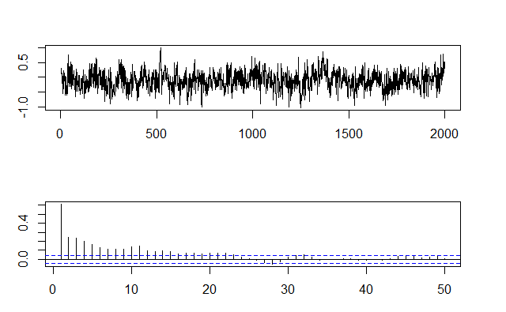

A long-memory (stationary) process and a non-stationary process: distinguishing a stationary, long-memory process from a non-stationary process is difficult in practice since both both have a autocorrelation function that dies out slowly and large values at zero frequency in the spectrum.

# model building strategy

## Wold Decomposition Thm

any discrete-time stationary process can be expressed as the sum of two uncorrelated processes, one deterministic and another indeterministic:

- deterministic: $\lim_{q \rightarrow \infty} \tau^2_q = 0$
- indeterministic: $\lim_{q \rightarrow \infty} \tau^2_q = var[X(t)]$, e.g., AR, MA, ARMA processes

## model build

- model specification: choose the classes of time series models that are appropriate for a given data series by looking at the time series plot and data collection processes
  - tentative and subject to revision
  - principle of parsimony
- model building: parameter estimation considering criteria such as least squares and ML
- model diagnostics: assessing quality of the model specified and estimated

## model specification: fitting a suitable model to an observed time series

### estimating autocovariance and autocorrelation functions

the theoretical autocorrelation function is an important descriptive tool for the properties of a stationary stochastic process.

provided the time series is stationary, sample autocorrelation function is an intuitive estimator of the theoretical autocorrelation function.

given a stationary process $\{x_1, \dots,x_N\}$, the **sample autocovariance coefficient** at lag k is given by

$$c_k=\sum_{t=1}^{N-k}(x_t-\bar{x})(x_{t+k}-\bar{x})/N$$

which is an intuitive estimator for $\gamma(k)$ at lag k. however, this estimator is biased $E[c_k] \ne \gamma(k)$. but $\lim_{N\rightarrow \infty}E[c_k]=$, thus the sample autocovariance function is asymptocally unbiased.

to estimate the autocorrelation function, we take $r_k=c_k/c_0$ as an estimator for $\rho(k): r_k \rightarrow \rho(k)$. but $r_k$ is generally biased and we only consider it when sampling from a purely random process where all theoretical autocorrelation coefficients are 0 except at lag 0.

$$E[r_k] \approx -1/N, var[r_k] \approx 1/N$$
- assess randomness of a stochastic process

$r_k \sim N(\mu, \sigma^2)$ as $N \rightarrow \infty$ under weak conditions. plotting out $\pm\frac{1.96}{N}$ with the autocorrelation coefficients can help determined if the process is truely random. Note that this is at $\alpha=5\%$ level and as we plot more coefficients, say 20, we expect 1 coefficient will fall out of the range and be significant. If we observed more than 1 significant coefficients, then we say the process is not random.

- identify a suitable class of models for a given time series
  - A correlogram with values of autocorrelation coefficients that do not come down to 0 quickly, indicates non-stationarity and that the time series need to be differenced.
  - for stationary time-series, compare the correlogram to that of the theoretical autocorrelation plot of various ARMA processes to choose the best model.
    - MA(q): “cuts off”
      - $r_1$ is significantly different from 0 but the rest $r_k$s are all close to 0, then MA(1) is good
    - AR(p): die out slowly/attenuate
      - $r_1, r_2,r_3, \dots,$ appear to be decreasing slowly, a AR(1) model is good
    - mixed ARMA: attenuate

the correlogram is also helpful in trying to identify appropriate models for a given time series realization. in particular, it is good for selecting the most appropriate type of auto-regressive integrated moving average (**ARIMA**) model.

- estimate the mean

although sample mean is used when estimating sample autocovariance and autocorrelation functions, sample mean is a potentially misleading statistic unless all systematic components have been removed. thus sample mean should only be considered for data to have come from a stationary process.

## fitting an autoregressive process

after estimating the autocorrelation function of a given time series, next step is to decide upon which model to use as a suitable model to the stochastic process.

if an AR process seem convincing, then there are two related questions:

- what is the order of the process?
- how can we estiamte the parameter of the process

### estimate parameters of an AR process

consider a AR(p) process with a mean $\mu$:

$$X(t)-\mu=\alpha_1(X(t-1))+\dots+\alpha_p (X(t-p)-\mu)+Y(t)$$

1.

Cryer JD, Chan KS (2008) [Time series analysis: With applications in r](https://books.google.com/books?id=MrNY3s2difIC), Springer.

2.

Chatfield C, Xing H (2019) [The analysis of time series: An introduction with r](https://books.google.com/books?id=llupDwAAQBAJ), CRC Press.

3.

Nielsen A (2019) [Practical time series analysis: Prediction with statistics and machine learning](https://books.google.com/books?id=odCwDwAAQBAJ), O’Reilly Media.